# 2_2_tsibbles_import_timeplots

# `tsibble` objects

## Installation

```r
install.packages("tsibble")
```

## Libraries used:

```r
# Loads tidyverse and tidyverse core libraries
library(tidyverse)

# Part of tidyverse but not of tidyverse's core. Needs to be loaded separately.
library(lubridate)

library(tsibble)
library(tsibbledata)

# Package of time series utilities created by Rob Hundman and the book authors.
# Part of the "tidyverts" package, which extends the tidyverse principles to
# time-series forecasting.
# In this session we will be using its "autoplot" function.
library(fable)

# Loads tidyverse data import methods
library(readxl)

# Loads the flights data set.
library(nycflights13)
```

## tsibble data structure

A *tsibble* is a time series object much easier to work with than `ts`, `xts` and other alternatives available in R. It **extends the concept of tibble**, adding additional properties that make it particularly fit for time series data.

**Time series**: sequential **registers of measurements** (for one or several variables) **over time** for **one or several observational units**

A tsibble object structures data in the following manner;

1. **An index**, which is a **variable with inherent ordering from past to present** (time-related)
2. **A key**, which is a **variable or set of variables** that **identifies observational units** unambiguously (optional).
3. **Measured variables**: numbers of interest.

Each **observation** is **uniquely identified** by a combination of **index** and **key**

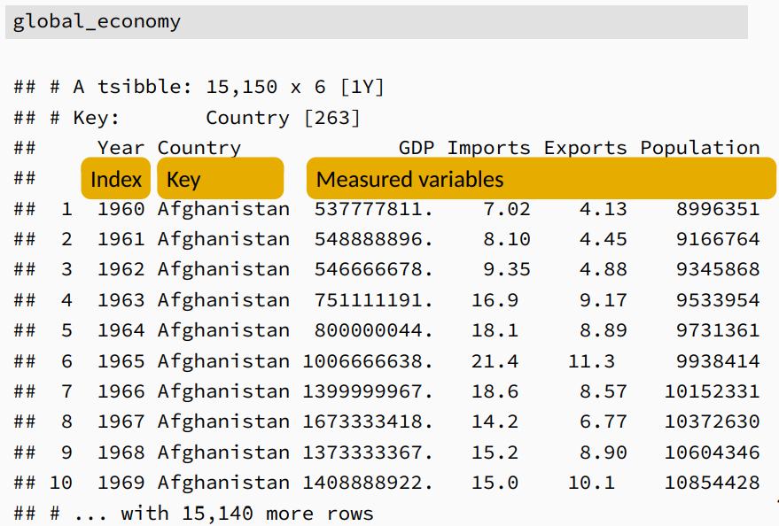

Figure 1: Global Economy Data. From [1]

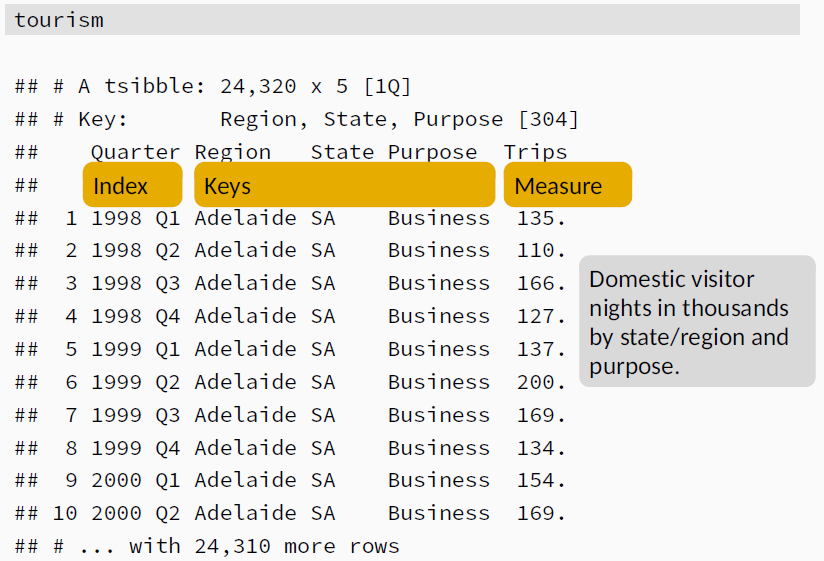

Figure 2: Australia Tourism Data. From [1]

## Creating a tsibble

### tsibble():

```r
data_1 <- tsibble(
  year = 2012:2016,
  y = c(123, 39, 78, 52, 110),
  index = year
)
data_1
```

```
## # A tsibble: 5 x 2 [1Y]
##    year     y
##   <int> <dbl>
## 1  2012   123
## 2  2013    39
## 3  2014    78
## 4  2015    52
## 5  2016   110
```

Note the line `A tsibble 5 x 2 [1Y]` The **[1Y]** indicates the frequency of the data sampling and helps us identify we are in fact dealing with a tsibble.

### as_tsibble():

We could also coherce an existing tibble or data.frame to a tsibble using `as_tsibble()`

```r
data_1 <- tibble(
  year = 2012:2016,
  y = c(123, 39, 78, 52, 110)
) %>%
as_tsibble(index = year)

data_1
```

```
## # A tsibble: 5 x 2 [1Y]
##    year     y
##   <int> <dbl>
## 1  2012   123
## 2  2013    39
## 3  2014    78
## 4  2015    52
## 5  2016   110
```

### Index variable: frequency of observations and time class functions.

For observations that are more frequent than once per year, we need to use a time class function on the index.

Table 1: **Functions for time index variables depending on frequency**

| Frequency | Function |
| --- | --- |
| Anual | `start:end` |
| Quartetly | `yearquarter()` |
| Monthly | `yearmonth()` |
| Weekly | `yearweek()` |
| Daily | `as_date()`, `ymd()` |
| Sub-daily | `as_datetime()`, `ymd_hms()` |

An interval is automatically obtained based on the corresponding time representation:

- `integer/numeric/ordered:` either “unit” or “year” `(Y)`
- `yearquarter/yearqtr:` “quarter” `(Q)`
- `yearmonth/yearmon:` “month” `(M)`
- `yearweek:` “week” `(W)`
- `Date:` “day” `(D)`
- `difftime:` “week” `(W)`, “day” `(D)`, “hour” `(h)`, “minute” `(m)`, “second” `(s)`
- `POSIXct/hms:` “hour” `(h)`, “minute” `(m)`, “second” `(s)`, “millisecond” `(us)`, “microsecond” `(ms)`
- `nanotime:` “nanosecond” `(ns)`

The examples that follow will hopefully bring some clarity to these concepts.

## Importing data with `read_csv` and `read_xlsx`

For the following example, please create a subfolder called `datasets` in your current working directoy and place there the datasets provided for this lesson.

### Passengers dataset

```r
passengers <- readr::read_csv("datasets/AirPassengers.csv")
```

```r
passengers
```

```
## # A tibble: 144 x 2
##    Month   `#Passengers`
##    <chr>           <dbl>
##  1 1949-01           112
##  2 1949-02           118
##  3 1949-03           132
##  4 1949-04           129
##  5 1949-05           121
##  6 1949-06           135
##  7 1949-07           148
##  8 1949-08           148
##  9 1949-09           136
## 10 1949-10           119
## # ... with 134 more rows
```

Note that the output is a tibble. To make it a tsibble, we need to convert the column month to a time index format. Since we are dealing with monthly data, we will use `yearmonth()`

```r
passengers <- passengers %>%

  # Transform the time varialbe from chr to yearmonth()
  mutate(Month = yearmonth(Month)) %>%

  # Rename the column #Passengers to have a better name (good practice)
  rename(n_pasengers = `#Passengers`)

# Convert to a tsibble
passengers <- as_tsibble(passengers, index = Month)

# Check result
passengers
```

```
## # A tsibble: 144 x 2 [1M]
##       Month n_pasengers
##       <mth>       <dbl>
##  1 1949 Jan         112
##  2 1949 Feb         118
##  3 1949 Mar         132
##  4 1949 Apr         129
##  5 1949 May         121
##  6 1949 Jun         135
##  7 1949 Jul         148
##  8 1949 Aug         148
##  9 1949 Sep         136
## 10 1949 Oct         119
## # ... with 134 more rows
```

Let us now create the time plot with `autoplot` (from the tsibble library)

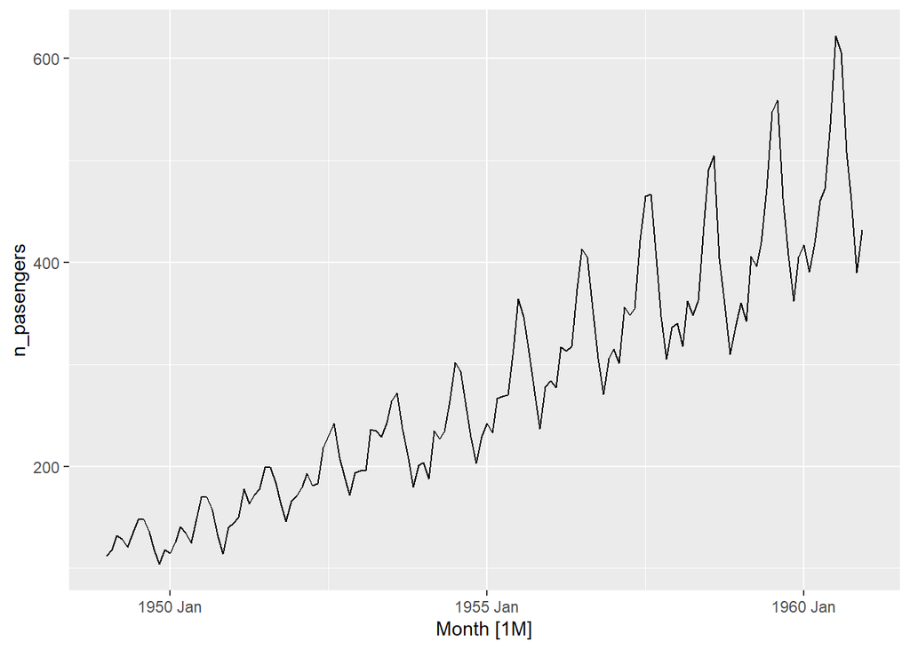

```r
autoplot(passengers, n_pasengers)
```

### Beijing pollution

```r
pollution <- readr::read_csv("datasets/Beijing_Pollution_TSeries.csv")
pollution
```

```
## # A tibble: 35,064 x 18
##       No  year month   day  hour PM2.5  PM10   SO2   NO2    CO    O3  TEMP  PRES
##    <dbl> <dbl> <dbl> <dbl> <dbl> <dbl> <dbl> <dbl> <dbl> <dbl> <dbl> <dbl> <dbl>
##  1     1  2013     3     1     0     4     4     4     7   300    77  -0.7 1023
##  2     2  2013     3     1     1     8     8     4     7   300    77  -1.1 1023.
##  3     3  2013     3     1     2     7     7     5    10   300    73  -1.1 1024.
##  4     4  2013     3     1     3     6     6    11    11   300    72  -1.4 1024.
##  5     5  2013     3     1     4     3     3    12    12   300    72  -2   1025.
##  6     6  2013     3     1     5     5     5    18    18   400    66  -2.2 1026.
##  7     7  2013     3     1     6     3     3    18    32   500    50  -2.6 1026.
##  8     8  2013     3     1     7     3     6    19    41   500    43  -1.6 1027.
##  9     9  2013     3     1     8     3     6    16    43   500    45   0.1 1028.
## 10    10  2013     3     1     9     3     8    12    28   400    59   1.2 1028.
## # ... with 35,054 more rows, and 5 more variables: DEWP <dbl>, RAIN <dbl>,
## #   wd <chr>, WSPM <dbl>, station <chr>
```

As before, we would like to transform it now into a tsibble. We need to create a time_stamp that will be used as index.

Since we have the components of the date in different columns, we will use the function `make_datetime`. For details see:

https://r4ds.had.co.nz/dates-and-times.html#creating-datetimes

```r
pollution <- pollution %>%

  #Step 1: create the time_stamp
  mutate(time_stamp = make_datetime(year, month, day, hour)) %>%

  #Step 2: reorder columns and drop timestamp components (keep only the newly created timestamp)
  select(time_stamp, everything(), -c(No, year, month, day, hour))  %>%

  #Step 3: convert to tsibble
  as_tsibble(index = time_stamp)

pollution
```

```
## # A tsibble: 35,064 x 14 [1h] <UTC>
##    time_stamp          PM2.5  PM10   SO2   NO2    CO    O3  TEMP  PRES  DEWP
##    <dttm>              <dbl> <dbl> <dbl> <dbl> <dbl> <dbl> <dbl> <dbl> <dbl>
##  1 2013-03-01 00:00:00     4     4     4     7   300    77  -0.7 1023  -18.8
##  2 2013-03-01 01:00:00     8     8     4     7   300    77  -1.1 1023. -18.2
##  3 2013-03-01 02:00:00     7     7     5    10   300    73  -1.1 1024. -18.2
##  4 2013-03-01 03:00:00     6     6    11    11   300    72  -1.4 1024. -19.4
##  5 2013-03-01 04:00:00     3     3    12    12   300    72  -2   1025. -19.5
##  6 2013-03-01 05:00:00     5     5    18    18   400    66  -2.2 1026. -19.6
##  7 2013-03-01 06:00:00     3     3    18    32   500    50  -2.6 1026. -19.1
##  8 2013-03-01 07:00:00     3     6    19    41   500    43  -1.6 1027. -19.1
##  9 2013-03-01 08:00:00     3     6    16    43   500    45   0.1 1028. -19.2
## 10 2013-03-01 09:00:00     3     8    12    28   400    59   1.2 1028. -19.3
## # ... with 35,054 more rows, and 4 more variables: RAIN <dbl>, wd <chr>,
## #   WSPM <dbl>, station <chr>
```

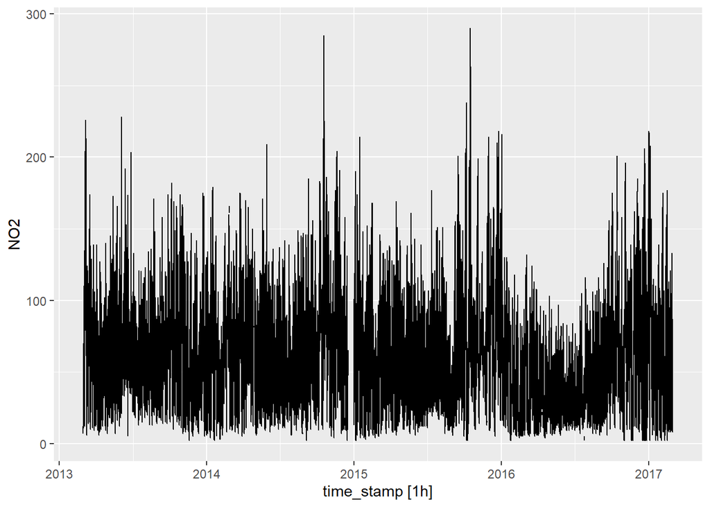

```r
autoplot(pollution, NO2)
```

**Question**: what is the problem when visualizing this data?

#### Average weekly values

If we start aggregating data, we will lose time resolution, but in turn we might get some clarity:

```r
NO2_weekly <- select(pollution, time_stamp, NO2) %>%

  # Step 1: Indicate level of aggregation desired in the index. In this case
  # we will start with a weekly aggregation:
  index_by(week = yearweek(time_stamp)) %>%

  # Step 2: aggregate variables with the desired output
  summarise(
    average_NO2 = mean(NO2, na.rm = TRUE), # Computes the mean NO2 levels for each calendar week.
  )

NO2_weekly
```

```
## # A tsibble: 210 x 2 [1W]
##        week average_NO2
##      <week>       <dbl>
##  1 2013 W09        56.8
##  2 2013 W10        97.8
##  3 2013 W11        82.0
##  4 2013 W12        55.2
##  5 2013 W13        72.2
##  6 2013 W14        60.0
##  7 2013 W15        44.7
##  8 2013 W16        55.1
##  9 2013 W17        59.0
## 10 2013 W18        45.6
## # ... with 200 more rows
```

Now lets use autoplot for the time plot. Autoplot is built on top of ggplot2, sharing similra grammar and being able to be combined with ggplo2 functions

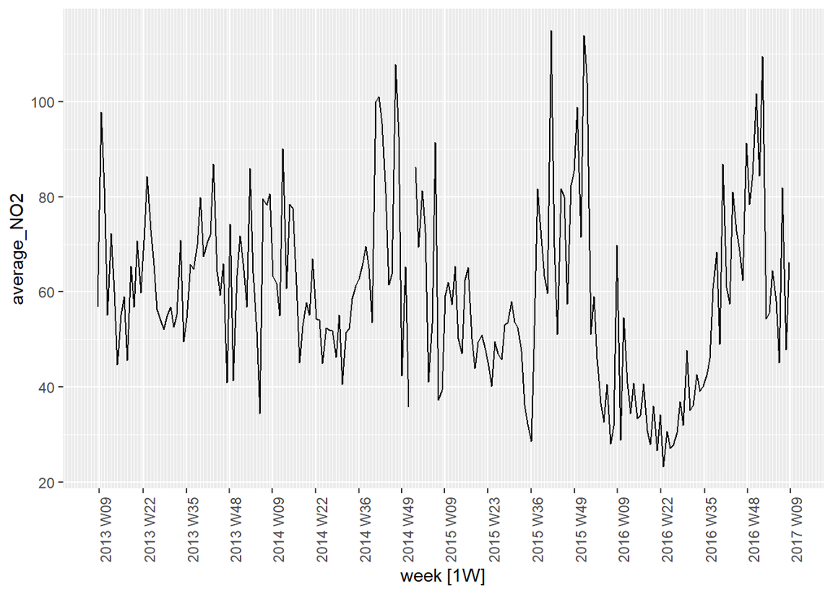

```r
autoplot(NO2_weekly, average_NO2) +

# Set the grid frequency for the x axis and its label format.
# The tsibble function scale_x_yearweek scales the x axis in CW according to the
# breaks we set
scale_x_yearweek(date_breaks = "3 month",
                  date_minor_breaks = "1 week") +

# Flip x-labels by 90 degrees
theme(axis.text.x = element_text(angle = 90))
```

#### EXERCISE 1 average monthly values:

Now you will repeat the process to aggregate monthly values (see separate excersises script)

```r
NO2_monthly <- select(pollution, time_stamp, NO2) %>%

  # Step 1: Indicate level of aggregation desired in the index. In this case
  # monthly aggregation
  index_by(Month = yearmonth(time_stamp)) %>%

  # Step 2: Aggregate variable with the desired output
  summarise(
    average_NO2 = mean(NO2, na.rm = TRUE),
  )

NO2_monthly
```

```
## # A tsibble: 48 x 2 [1M]
##       Month average_NO2
##       <mth>       <dbl>
##  1 2013 Mar        74.8
##  2 2013 Apr        53.3
##  3 2013 May        61.0
##  4 2013 Jun        72.9
##  5 2013 Jul        55.1
##  6 2013 Aug        56.8
##  7 2013 Sep        64.2
##  8 2013 Oct        73.6
##  9 2013 Nov        60.0
## 10 2013 Dec        62.3
## # ... with 38 more rows
```

#### EXERCISE 2: plotting monthly aggregation

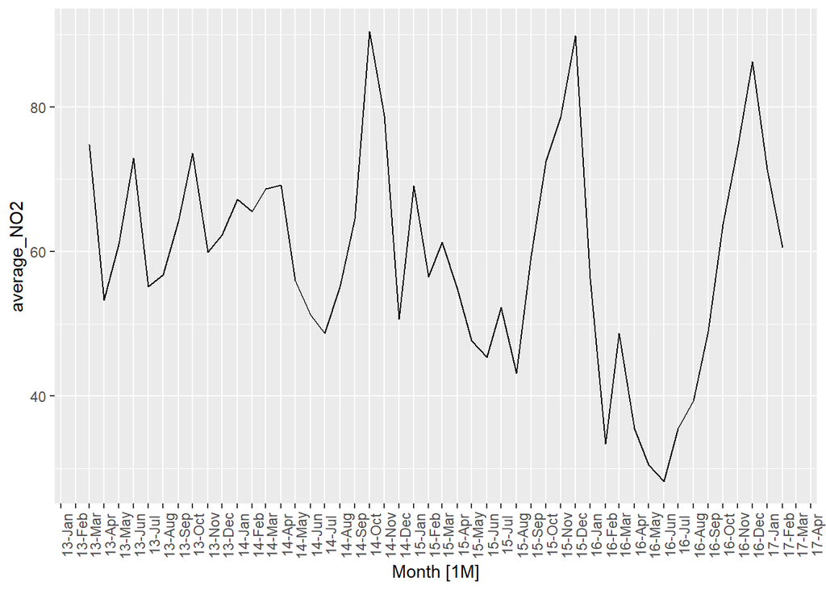

```r
# Autoplot function from library tsibble
autoplot(NO2_monthly, average_NO2) +

# Set the grid frequency for the x axis and its label format
scale_x_yearmonth(date_breaks = "1 month",
                  date_minor_breaks = "1 month", # Check what happens if you comment this line
                  date_labels = "%y-%b") +

# Flip x-labels by 90 degrees
theme(axis.text.x = element_text(angle = 90))
```

#### Average quarterly values:

```r
NO2_quarterly <- select(pollution, time_stamp, NO2) %>% #Selecting variables of interest

  # Step 1: Indicate level of aggregation desired in the index. In this case
  # monthly aggregation
  index_by(Quarter = yearquarter(time_stamp)) %>%

  # Step 2: Aggregate variable with the desired output
  summarise(
    average_NO2 = mean(NO2, na.rm = TRUE),
  )

NO2_quarterly
```

```
## # A tsibble: 17 x 2 [1Q]
##    Quarter average_NO2
##      <qtr>       <dbl>
##  1 2013 Q1        74.8
##  2 2013 Q2        62.4
##  3 2013 Q3        58.7
##  4 2013 Q4        65.3
##  5 2014 Q1        67.3
##  6 2014 Q2        58.5
##  7 2014 Q3        56.0
##  8 2014 Q4        77.0
##  9 2015 Q1        62.5
## 10 2015 Q2        49.3
## 11 2015 Q3        51.5
## 12 2015 Q4        80.3
## 13 2016 Q1        46.2
## 14 2016 Q2        31.4
## 15 2016 Q3        41.1
## 16 2016 Q4        74.9
## 17 2017 Q1        66.3
```

```r
quarter_seq = yearquarter(NO2_quarterly[["Quarter"]][1]) + seq(0, nrow(NO2_quarterly), by = 1)
quarter_seq
```

```
## <yearquarter[18]>
##  [1] "2013 Q1" "2013 Q2" "2013 Q3" "2013 Q4" "2014 Q1" "2014 Q2" "2014 Q3"
##  [8] "2014 Q4" "2015 Q1" "2015 Q2" "2015 Q3" "2015 Q4" "2016 Q1" "2016 Q2"
## [15] "2016 Q3" "2016 Q4" "2017 Q1" "2017 Q2"
## # Year starts on: January
```

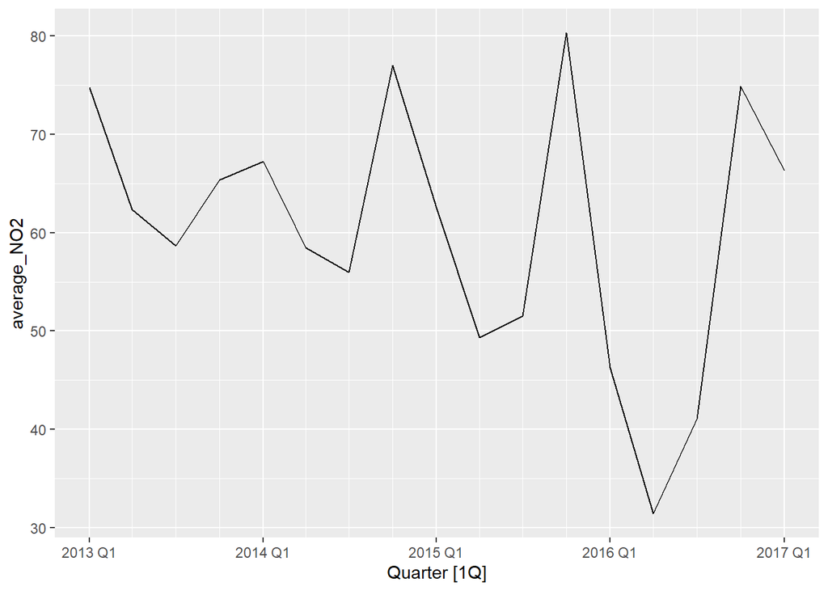

```r
autoplot(NO2_quarterly, average_NO2) +

scale_x_yearquarter(date_breaks = "1 year",

                    # For quarters it is best to manually construct the sequence
                    minor_breaks = quarter_seq)
```

### Singapore COVID cases

This time we will be reading from an excel file:

```r
singapore_covid <- read_xlsx("datasets/Covid-19_SG_NoGraphs.xlsx")
singapore_covid
```

```
## # A tibble: 727 x 36
##    Date   `Daily Confirmed` `False Positives~ `Cumulative Conf~ `Daily Discharg~
##    <chr>              <dbl>             <dbl>             <dbl>            <dbl>
##  1 2020-~                 1                NA                 1               NA
##  2 2020-~                 2                NA                 3                0
##  3 2020-~                 1                NA                 4                0
##  4 2020-~                 0                NA                 4                0
##  5 2020-~                 1                NA                 5                0
##  6 2020-~                 2                NA                 7                0
##  7 2020-~                 3                NA                10                0
##  8 2020-~                 3                NA                13                0
##  9 2020-~                 3                NA                16                0
## 10 2020-~                 2                NA                18                0
## # ... with 717 more rows, and 31 more variables:
## #   Passed but not due to COVID <dbl>, Cumulative Discharged <dbl>,
## #   Discharged to Isolation <dbl>, Still Hospitalised <dbl>,
## #   Daily Deaths <dbl>, Cumulative Deaths <dbl>, Tested positive demise <dbl>,
## #   Daily Imported <dbl>, Daily Local transmission <dbl>,
## #   Local cases residing in dorms MOH report <dbl>,
## #   Local cases not residing in doms MOH report <dbl>, ...
```

We have a tibble. Now you will practice converting it to a tsibble.

#### EXERCISE 3: convert to a tsibble

```r
singapore_covid <- singapore_covid  %>%

  #Step 1: create Date item using ymd
  mutate(time_stamp=ymd(Date))  %>%

  #Step 2: select items of interest
  select(time_stamp, `Daily Confirmed`) %>%

  #Step 3: convert to tsibble
  as_tsibble(index = time_stamp)

singapore_covid
```

```
## # A tsibble: 727 x 2 [1D]
##    time_stamp `Daily Confirmed`
##    <date>                 <dbl>
##  1 2020-01-23                 1
##  2 2020-01-24                 2
##  3 2020-01-25                 1
##  4 2020-01-26                 0
##  5 2020-01-27                 1
##  6 2020-01-28                 2
##  7 2020-01-29                 3
##  8 2020-01-30                 3
##  9 2020-01-31                 3
## 10 2020-02-01                 2
## # ... with 717 more rows
```

#### EXERCISE 4: aggregating by month

```r
singapore_monthly <- singapore_covid %>%

  # Step 1: Indicate level of aggregation desired in the index. In this case
  # monthly aggregation
  index_by(month = yearmonth(time_stamp)) %>%

  # Step 2: Aggregate variable with the desired output
  summarise(
    monthly_confirmed = sum(`Daily Confirmed`, na.rm = TRUE),
  )
singapore_monthly
```

```
## # A tsibble: 25 x 2 [1M]
##       month monthly_confirmed
##       <mth>             <dbl>
##  1 2020 Jan                16
##  2 2020 Feb                86
##  3 2020 Mar               824
##  4 2020 Apr             15243
##  5 2020 May             18750
##  6 2020 Jun              9023
##  7 2020 Jul              8300
##  8 2020 Aug              4607
##  9 2020 Sep               996
## 10 2020 Oct               250
## # ... with 15 more rows
```

#### Plotting monthly aggregation - method 1

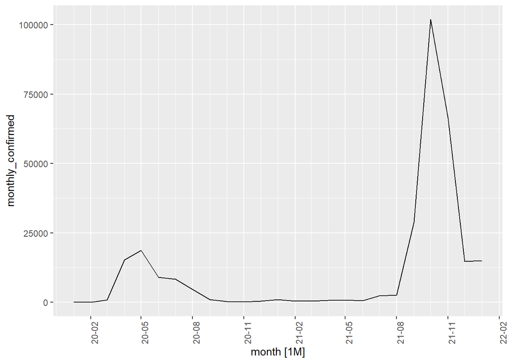

```r
autoplot(singapore_monthly, monthly_confirmed) +

# Set the grid frequency for the x axis and its label format
scale_x_yearmonth(date_breaks = "3 month",
                  date_minor_breaks = "1 month",
                  date_labels = "%y-%m") +

# Flip x-labels by 90 degrees
theme(axis.text.x = element_text(angle = 90))
```

#### Plotting monthly aggregation - method 2

If we want to have a better control over the x-axis labels, the most effective method is to generate our own monthly sequence

```r
#Lets define the sequence of months:
year_month_seq <- yearmonth(singapore_monthly[[1]][1]) + seq(0, nrow(singapore_monthly), by = 3)
year_month_seq
```

```
## <yearmonth[9]>
## [1] "2020 Jan" "2020 Apr" "2020 Jul" "2020 Oct" "2021 Jan" "2021 Apr" "2021 Jul"
## [8] "2021 Oct" "2022 Jan"
```

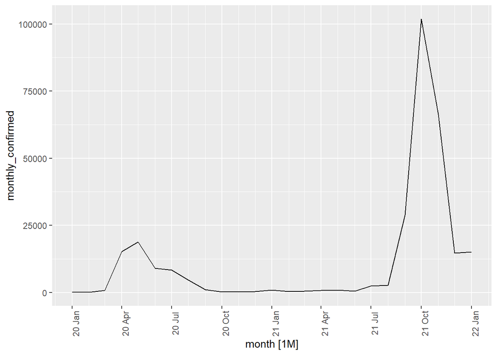

```r
autoplot(singapore_monthly, monthly_confirmed) +

# Set the grid frequency for the x axis and its label format
                  # Appropriately defined sequence
scale_x_yearmonth(breaks = year_month_seq,
                  date_minor_breaks = "1 month",
                  date_labels = "%y %b") +

# Flip x-labels by 90 degrees
theme(axis.text.x = element_text(angle = 90))
```

### Fuel weekly prices

In this case we will be dealing with an excel were that has text at the end of the column containing dates. This will raise an error when creating a tsibble:

```r
fuel_prices <- read_xlsx("datasets/Weekly Fuel Prices.xlsx")

fuel_prices
```

```
## # A tibble: 883 x 3
##    Date  `Petrol (USD)` `Diesel (USD)`
##    <chr>          <dbl>          <dbl>
##  1 37781           74.6           76.8
##  2 37788           74.5           76.7
##  3 37795           74.4           76.6
##  4 37802           74.4           76.5
##  5 37809           74.3           76.5
##  6 37816           74.2           76.4
##  7 37823           75.1           76.9
##  8 37830           75.1           76.9
##  9 37837           75.1           76.8
## 10 37844           75.4           77.1
## # ... with 873 more rows
```

What happened? The first column in excel is contaminated and mixes dates with a string at the end. The read_xlsx function is therefore confused about the datatype within excel of this particular column and therefore reads it as “General”.

When a date in Excel is converted to “General” format, its converted to an integer number. This is because excel stores dates as sequential serial numbers so that they can be used in calculations (actualy this approach is the standard for dealing with data operations). By default January 1st, 1900 is 1 in excel. read_xlsx() is importing the data in this format.

To fix this we can simply provide the additional argument `col_types` to the read_xlsx function (you can check all the options either in internet or using ?read_xlsx in the console).

```r
fuel_prices <- read_xlsx("datasets/Weekly Fuel Prices.xlsx",
                         col_types = c ("date", "numeric", "numeric"))

fuel_prices
```

```
## # A tibble: 883 x 3
##    Date                `Petrol (USD)` `Diesel (USD)`
##    <dttm>                       <dbl>          <dbl>
##  1 2003-06-09 00:00:00           74.6           76.8
##  2 2003-06-16 00:00:00           74.5           76.7
##  3 2003-06-23 00:00:00           74.4           76.6
##  4 2003-06-30 00:00:00           74.4           76.5
##  5 2003-07-07 00:00:00           74.3           76.5
##  6 2003-07-14 00:00:00           74.2           76.4
##  7 2003-07-21 00:00:00           75.1           76.9
##  8 2003-07-28 00:00:00           75.1           76.9
##  9 2003-08-04 00:00:00           75.1           76.8
## 10 2003-08-11 00:00:00           75.4           77.1
## # ... with 873 more rows
```

There are still some problems we need to deal with in the `Date` column.

- Irregular sampling intervals.
- NA Values.

#### Removing NA Values

Due to the formatting of the original dataframe, we may check that the last two rows of the tibble are NA values:

```r
# Find the location of NA values within the tibble
NAindex <- which(is.na(fuel_prices$Date))

NAindex # Index of the rows containing NA values in the date column
```

```
## [1] 882 883
```

```r
nrow(fuel_prices) # number of rows in fuel prices
```

```
## [1] 883
```

Seeing the results above, it appears that it is the last rows of the dataset that are contaminated.

```r
tail(fuel_prices)
```

```
## # A tibble: 6 x 3
##   Date                `Petrol (USD)` `Diesel (USD)`
##   <dttm>                       <dbl>          <dbl>
## 1 2020-03-30 00:00:00           112.           119.
## 2 2020-04-06 00:00:00           110.           117.
## 3 2020-04-13 00:00:00           109.           116.
## 4 2020-04-20 00:00:00           109.           116.
## 5 NA                             NA             NA
## 6 NA                             NA             NA
```

```r
fuel_prices <- filter(fuel_prices, !is.na(Date))

tail(fuel_prices)
```

```
## # A tibble: 6 x 3
##   Date                `Petrol (USD)` `Diesel (USD)`
##   <dttm>                       <dbl>          <dbl>
## 1 2020-03-16 00:00:00           120.           124.
## 2 2020-03-23 00:00:00           120.           123.
## 3 2020-03-30 00:00:00           112.           119.
## 4 2020-04-06 00:00:00           110.           117.
## 5 2020-04-13 00:00:00           109.           116.
## 6 2020-04-20 00:00:00           109.           116.
```

#### Irregular time intervals

Lets compute the difference between subsequent date values. For this we will first introduce the `lag()` function to shift by 1 a vector of the tibble:

```r
# Date values
fuel_prices[[1]][1:5]
```

```
## [1] "2003-06-09 UTC" "2003-06-16 UTC" "2003-06-23 UTC" "2003-06-30 UTC"
## [5] "2003-07-07 UTC"
```

```r
# Lagged date values
lag(fuel_prices[[1]], n = 1)[1:5]
```

```
## [1] NA               "2003-06-09 UTC" "2003-06-16 UTC" "2003-06-23 UTC"
## [5] "2003-06-30 UTC"
```

```r
# Difference in time values
time_diff <- fuel_prices[[1]]- lag(fuel_prices[[1]], n = 1)
time_diff[1:5]
```

```
## Time differences in days
## [1] NA  7  7  7  7
```

```r
min(time_diff, na.rm = TRUE) # Check what happens if we remove this
```

```
## Time difference of 5 days
```

```r
max(time_diff, na.rm = TRUE) # Check what happens if we remove this
```

```
## Time difference of 9 days
```

In conclusion, we have irregular sampling intervals. tsibble will generate problems when trying coerce this tibble to a tsibble unless we specify `regular = FALSE`.

```r
fuel_prices <- as_tsibble(fuel_prices, regular = FALSE, index = Date)
fuel_prices
```

```
## # A tsibble: 881 x 3 [!] <UTC>
##    Date                `Petrol (USD)` `Diesel (USD)`
##    <dttm>                       <dbl>          <dbl>
##  1 2003-06-09 00:00:00           74.6           76.8
##  2 2003-06-16 00:00:00           74.5           76.7
##  3 2003-06-23 00:00:00           74.4           76.6
##  4 2003-06-30 00:00:00           74.4           76.5
##  5 2003-07-07 00:00:00           74.3           76.5
##  6 2003-07-14 00:00:00           74.2           76.4
##  7 2003-07-21 00:00:00           75.1           76.9
##  8 2003-07-28 00:00:00           75.1           76.9
##  9 2003-08-04 00:00:00           75.1           76.8
## 10 2003-08-11 00:00:00           75.4           77.1
## # ... with 871 more rows
```

#### EXERCISE 5: Converting irregular data to regular data by aggregation

Aggregating irregularly sampled data to a higher time unit (e.g. data sampled at different day intervals) can be a method to turn it into regularly data. In this case, we will aggregate to mohtly data

```r
fuel_monthly <- fuel_prices %>%

  # Step 1: Indicate level of aggregation desired in the index. In this case
  # monthly aggregation
  index_by(Month = yearmonth(Date)) %>%

  # Step 2: Aggregate variable with the desired output
  summarise(
    avg_petrol_USD = mean(`Petrol (USD)`, na.rm = TRUE), # Backticks for spaces in Petrol (USD)
    avg_diesel_USD = mean(`Diesel (USD)`, na.rm = TRUE) # Backticks for spaces in Diesel (USD)
  )

fuel_monthly
```

```
## # A tsibble: 203 x 3 [1M]
##       Month avg_petrol_USD avg_diesel_USD
##       <mth>          <dbl>          <dbl>
##  1 2003 Jun           74.5           76.6
##  2 2003 Jul           74.7           76.7
##  3 2003 Aug           75.6           77.3
##  4 2003 Sep           76.2           77.6
##  5 2003 Oct           76.1           77.5
##  6 2003 Nov           76.0           77.5
##  7 2003 Dec           76.0           77.6
##  8 2004 Jan           76.1           77.8
##  9 2004 Feb           76.5           78.0
## 10 2004 Mar           77.1           78.6
## # ... with 193 more rows
```

#### EXERCISE 6: autoplot with several variables

```r
#Lets define the sequence of months:
year_month_seq <- yearmonth(fuel_monthly[[1]][1]) + seq(0, nrow(fuel_monthly), by = 6)
year_month_seq
```

```
## <yearmonth[34]>
##  [1] "2003 Jun" "2003 Dec" "2004 Jun" "2004 Dec" "2005 Jun" "2005 Dec"
##  [7] "2006 Jun" "2006 Dec" "2007 Jun" "2007 Dec" "2008 Jun" "2008 Dec"
## [13] "2009 Jun" "2009 Dec" "2010 Jun" "2010 Dec" "2011 Jun" "2011 Dec"
## [19] "2012 Jun" "2012 Dec" "2013 Jun" "2013 Dec" "2014 Jun" "2014 Dec"
## [25] "2015 Jun" "2015 Dec" "2016 Jun" "2016 Dec" "2017 Jun" "2017 Dec"
## [31] "2018 Jun" "2018 Dec" "2019 Jun" "2019 Dec"
```

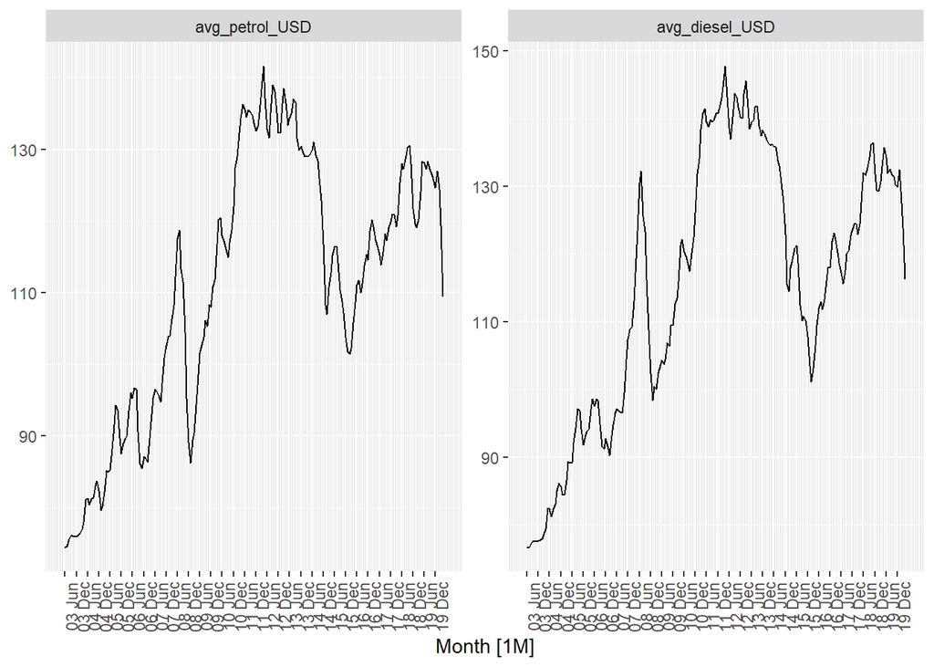

```r
autoplot(fuel_monthly, vars(avg_petrol_USD, avg_diesel_USD)) +

# Set the grid frequency for the x axis and its label format
                  # Appropriately defined sequence
scale_x_yearmonth(breaks = year_month_seq,
                  date_minor_breaks = "1 month",
                  date_labels = "%y %b") +

# Flip x-labels by 90 degrees
theme(axis.text.x = element_text(angle = 90))
```

##### EXAMPLE: wide to long data: `pivot_longer()`

The distinction between *wide* and *long* data is not always clear, but this dataset is a good example to illustrate it and to show the different behaviour of the autoplot function when dealing with long data.

We could consider the current formatting of this fuel prices to be wide data because for each point in time (index) we have two variables: the prices of diesel and petrol fuel. That is, two columns.

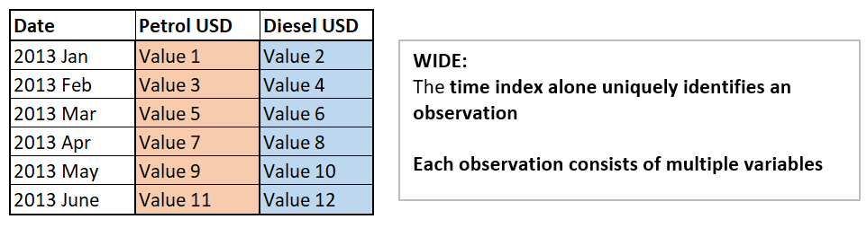

Figure 3: Example of wide data

We could, however, flip this and have **two observations for each point in time** that we would uniquely identify by adding a key. For each index we would only have 1 variable. The dataframe of course, would be longer. Hence the name *long*.

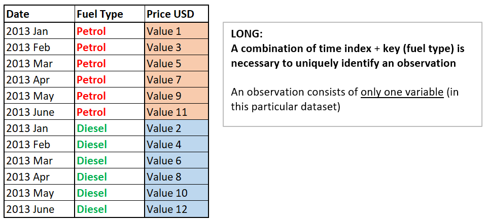

Figure 4: Example of long data

Let us *pivot* the data from wide to long format using `pivot_longer()` from the `tydyr` package. Please consider this an example and not something you need to absolutely master. We are doing this to show how longer data behaves with the `autoplot` function from `fable` that we are using throughout the lesson.

```r
fuel_monthly_long <-
  fuel_monthly %>%

  # Renames the columns so that they are an appropriate key in long format
  rename(petrol = avg_petrol_USD, diesel = avg_diesel_USD) %>%

  # Piivots the data
    # names_to: indicates that the column names will be moved to a new column
    # named "Fuel"
    # values_to: indicates that the values of each obervation will be moves to
    # a new column valles "avg_price_USD".
  pivot_longer(c(petrol, diesel), names_to = "Fuel", values_to = "avg_price_USD") %>%

  # Updates the tsibble object, allowing us to specify a key
  update_tsibble(index = Month, key = Fuel)

# Inspect_result
fuel_monthly_long
```

```
## # A tsibble: 406 x 3 [1M]
## # Key:       Fuel [2]
##       Month Fuel   avg_price_USD
##       <mth> <chr>          <dbl>
##  1 2003 Jun diesel          76.6
##  2 2003 Jul diesel          76.7
##  3 2003 Aug diesel          77.3
##  4 2003 Sep diesel          77.6
##  5 2003 Oct diesel          77.5
##  6 2003 Nov diesel          77.5
##  7 2003 Dec diesel          77.6
##  8 2004 Jan diesel          77.8
##  9 2004 Feb diesel          78.0
## 10 2004 Mar diesel          78.6
## # ... with 396 more rows
```

The process could be reversed using the function `pivot_wider()` of the same package. As a sidenote, the `tidyr()` package is a part of `tidyverse` and has fuctions to help turn untidy data into tidy data.

##### EXAMPLE: autoplot with long data

Instead of two graphs (what we obtained with wide data) we obtain one graph and one curve per key.

```
## Plot variable not specified, automatically selected `.vars = avg_price_USD`
```

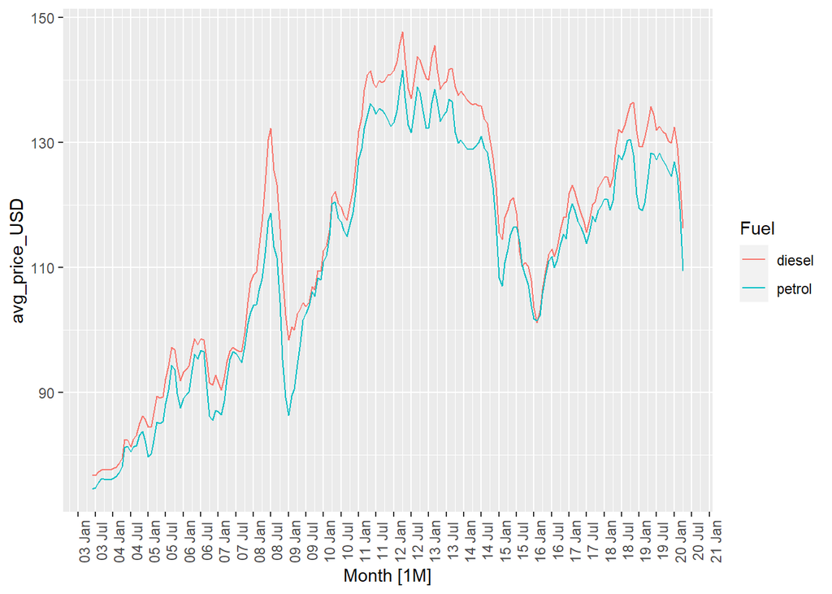

```r
# AUTOPLOT WITH LONG DATA

autoplot(fuel_monthly_long) +

# Set the grid frequency for the x axis and its label format
                  # Appropriately defined sequence
scale_x_yearmonth(date_breaks= "6 month",
                  date_minor_breaks = "3 month",
                  date_labels = "%y %b") +

# Flip x-labels by 90 degrees
theme(axis.text.x = element_text(angle = 90))
```

## Creating a tsibble with data that has repeated time indexes and needs a key.

Let us consider the flights dataset from the `nycflights13` package loaded at the beginnig of this workbook (you might need to install it).

```r
flights
```

```
## # A tibble: 336,776 x 19
##     year month   day dep_time sched_dep_time dep_delay arr_time sched_arr_time
##    <int> <int> <int>    <int>          <int>     <dbl>    <int>          <int>
##  1  2013     1     1      517            515         2      830            819
##  2  2013     1     1      533            529         4      850            830
##  3  2013     1     1      542            540         2      923            850
##  4  2013     1     1      544            545        -1     1004           1022
##  5  2013     1     1      554            600        -6      812            837
##  6  2013     1     1      554            558        -4      740            728
##  7  2013     1     1      555            600        -5      913            854
##  8  2013     1     1      557            600        -3      709            723
##  9  2013     1     1      557            600        -3      838            846
## 10  2013     1     1      558            600        -2      753            745
## # ... with 336,766 more rows, and 11 more variables: arr_delay <dbl>,
## #   carrier <chr>, flight <int>, tailnum <chr>, origin <chr>, dest <chr>,
## #   air_time <dbl>, distance <dbl>, hour <dbl>, minute <dbl>, time_hour <dttm>
```

As we can see, we have all the time information split across different columns. We want to transform this into a tsibble. For this, we need to:

1. Create a time object (date, date-time…) that will act as an index
2. Define a minimum set of labels that act as a “key” to uniquely identify the observational units.

Let us begin by creating the timestamp

```r
flights_ts <-
  flights %>%

  #Create timestamp
  mutate(time = make_datetime(year, month, day, hour, minute)) %>%

  #Rearrange columns and drop previous time information columns
  select(time, everything(), -c(year, month, day, hour, minute))

flights_ts
```

```
## # A tibble: 336,776 x 15
##    time                dep_time sched_dep_time dep_delay arr_time sched_arr_time
##    <dttm>                 <int>          <int>     <dbl>    <int>          <int>
##  1 2013-01-01 05:15:00      517            515         2      830            819
##  2 2013-01-01 05:29:00      533            529         4      850            830
##  3 2013-01-01 05:40:00      542            540         2      923            850
##  4 2013-01-01 05:45:00      544            545        -1     1004           1022
##  5 2013-01-01 06:00:00      554            600        -6      812            837
##  6 2013-01-01 05:58:00      554            558        -4      740            728
##  7 2013-01-01 06:00:00      555            600        -5      913            854
##  8 2013-01-01 06:00:00      557            600        -3      709            723
##  9 2013-01-01 06:00:00      557            600        -3      838            846
## 10 2013-01-01 06:00:00      558            600        -2      753            745
## # ... with 336,766 more rows, and 9 more variables: arr_delay <dbl>,
## #   carrier <chr>, flight <int>, tailnum <chr>, origin <chr>, dest <chr>,
## #   air_time <dbl>, distance <dbl>, time_hour <dttm>
```

As it stands, we still have a tibble. Let us try to coerce it to a tsibble:

```r
flights_ts <- as_tsibble(flights_ts, index = time)
```

```
## Error: A valid tsibble must have distinct rows identified by key and index.
## i Please use `duplicates()` to check the duplicated rows.
```

The error message is letting us know that there are repeated time indexes. If this occurs, has we have seen, we need to add a key to the tsibble data structure to uniquely identify the observational units.

First, let us check how many indexes are repeated. We can do this by using the `duplicates()` function of the tsibble package:

```r
nrow(flights_ts)
```

```
## [1] 336776
```

```r
nrow(duplicates(flights_ts, index = time))
```

```
## [1] 275432
```

flights_ts has 336776 rows and there are 275432 rows that have an index that repeats somewhere else in the data.

To solve this situation, we need to include the minimum amount of keys that identify uniquely the observational units and solve this lack of coherence in the data. Let us start introducing the variable `flight` (the flight number) as part of the key

```r
flights_ts <- as_tsibble(flights_ts, index = time, key = flight)
```

```
## Error: A valid tsibble must have distinct rows identified by key and index.
## i Please use `duplicates()` to check the duplicated rows.
```

We still get the same error, although this time we have a lower amount of duplicates:

```r
nrow(flights_ts)
```

```
## [1] 336776
```

```r
nrow(duplicates(flights_ts, index = time, key = flight))
```

```
## [1] 226
```

There are 336776 rows in the data and 226 rows have a combination of index + flight that repeats.

The reason for this is that flight numbers are made up of a code of 4 numbers preceded by the identification of the carrier. Thus, if we include the aircraft carrier as part of the key, we will now have no repetitions:

```r
nrow(duplicates(flights_ts, index = time, key = c(carrier,flight)))
```

```
## [1] 0
```

And NOW we can finally coherce our data to a tsibble taking this into account:

```r
flights_ts <-
  flights_ts %>%

  #coerce to a tsibble
  as_tsibble(index = time, key = c(carrier, flight)) %>%

  #rearrange rows to have the key values at the beginning
  select(time, carrier, flight, everything())

flights_ts
```

```
## # A tsibble: 336,776 x 15 [1m] <UTC>
## # Key:       carrier, flight [5,725]
##    time                carrier flight dep_time sched_dep_time dep_delay arr_time
##    <dttm>              <chr>    <int>    <int>          <int>     <dbl>    <int>
##  1 2013-11-03 15:40:00 9E        2900     1531           1540        -9     1653
##  2 2013-11-04 15:40:00 9E        2900     1539           1540        -1     1712
##  3 2013-11-05 15:40:00 9E        2900     1548           1540         8     1708
##  4 2013-11-06 15:40:00 9E        2900     1535           1540        -5     1657
##  5 2013-11-07 15:40:00 9E        2900     1549           1540         9     1733
##  6 2013-11-08 15:40:00 9E        2900     1539           1540        -1     1706
##  7 2013-11-09 15:40:00 9E        2900     1535           1540        -5     1714
##  8 2013-11-10 15:40:00 9E        2900     1538           1540        -2     1718
##  9 2013-11-11 15:40:00 9E        2900     1527           1540       -13     1710
## 10 2013-11-12 15:40:00 9E        2900     1535           1540        -5     1709
## # ... with 336,766 more rows, and 8 more variables: sched_arr_time <int>,
## #   arr_delay <dbl>, tailnum <chr>, origin <chr>, dest <chr>, air_time <dbl>,
## #   distance <dbl>, time_hour <dttm>
```